# Flattening the Curve

## Problem Statement

As demonstrated by these past few months, epidemic diseases can have drastic effects on people all around the world. As governments haved rushed to respond to COVID-19, we have also seen that not only are lives affected through the sickness itself, but the economic impacts have also strained society. In order to help limit the spread of the disease while keeping the economy as funictioning as possible, *non-pharmaceutical interventions (NPIs)* can be an effective way to keep people safe while scientists find a cure.

In response, we have decided to look at a strategy to determine the least number of groups to close that minimizes the chance of spreading the infection while allowing society to function as much as possible. We also know that our hospital can only hold up to 50 people and that infected people will need a bed there from day 7 to day 10 of their infection. As such, our ultimate goal is to find the **maximum group headcount** to open while keeping peak hospitalization within capacity.

```python
import pandas as pd
import numpy as np
```

## Data

In order to perform our analysis, we looked at data under three scenarios of government intervention. The following datasets contain data corresponding to peak hospitalization at each *stage of intervention*:

- **Early Intervention** has **2** initially infected people
- **Late Intervention** has **20** initially infected people
- **Very Late Intervention** has **40** initially infected people

```python
data_2 = pd.read_csv('init_infect_2.csv') # contains data for early intervention
data_20 = pd.read_csv('init_infect_20.csv') # contains data for late intervention
data_40 = pd.read_csv('init_infect_40.csv') # contains data for very late intervention
```

### Variables

These datasets contain valuable information about the following variables

- x_values: headcount threshold of a group to close
- max_bed_demand: largest number of beds required throughout the entire simulation of a virus epidmemic

Let's preview what the dataset looks like:

```python
data_2.head()
```

|  | x_values | max_bed_demand |
| --- | --- | --- |
| 0 | 2 | 2.0 |
| 1 | 3 | 2.0 |
| 2 | 4 | 2.0 |
| 3 | 5 | 2.1 |
| 4 | 6 | 2.1 |

Since all the data csv files are in the same format, data_2, data_20 and data_40 will have the same column labels, but with a different number of initial infections.

## Analysis

Given this data for the three scenarios, we analyzed the correlation between the minimum headcount in a closed group and the maximum bed demand under each scenario.

For the following graphs, note that the red line represents the **peak hospital capacity** at **50 beds**.

### 1. Early Intervention

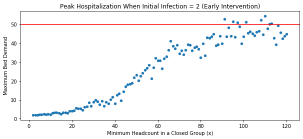

```python
plot_2 = data_2.plot.scatter(x='x_values', y='max_bed_demand',
                             figsize=(10,4),
                            title='Peak Hospitalization When Initial Infection = 2 (Early Intervention)')
plot_2.set_xlabel("Minimum Headcount in a Closed Group (x)")
plot_2.set_ylabel("Maximum Bed Demand")
plot_2.axhline(y=50,color="r")
```

As we can see from this scatterplot, as the minimum headcount in a closed group rises, so too does the maximum bed demand. Given our threshold of maximum bed demand as 50, we can look at the data to find the maximum headcount to allow for an open group.

```python
max_x_2 = data_2[ data_2.max_bed_demand <= 50 ].x_values.max()
max_x_2
```

```
120
```

From our data, we have determined for early intervention that the maximum headcount in an open group should be less than **120** people.

### 2. Late Intervention

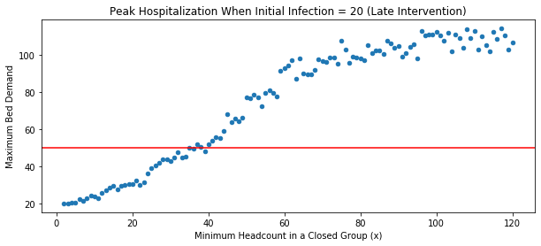

```python
plot_20 = data_20.plot.scatter(x='x_values', y='max_bed_demand',
                             figsize=(10,4),
                            title='Peak Hospitalization When Initial Infection = 20 (Late Intervention)')
plot_20.set_xlabel("Minimum Headcount in a Closed Group (x)")
plot_20.set_ylabel("Maximum Bed Demand")
plot_20.axhline(y=50,color="r")
```

As we can see from this scatterplot, there is the same positive correlation between minimum headcount in a closed group and the maximum bed demand. However, this time, we can see that the graph rapidly reached the peak hospital capacity at a much lower headcount.

```python
max_x_20 = data_20[ data_20.max_bed_demand <= 50 ].x_values.max()
max_x_20
```

```
39
```

From our data, we have determined for late intervention that the maximum headcount for an open group should be less than **39** people.

### 3. Very Late Intervention

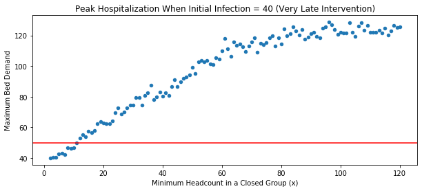

```python
plot_40 = data_40.plot.scatter(x='x_values', y='max_bed_demand',
                             figsize=(10,4),
                            title='Peak Hospitalization When Initial Infection = 40 (Very Late Intervention)')
plot_40.set_xlabel("Minimum Headcount in a Closed Group (x)")
plot_40.set_ylabel("Maximum Bed Demand")
plot_40.axhline(y=50,color="r")
```

As we can see from this scatterplot, again we have the same positive correlation between maximum headcount in an open group and the maximum bed demand. As we may expect, under this scenario, the peak hospital capacity is reached even faster and at a significantly lower maximum headcount.

```python
max_x_40 = data_40[ data_40.max_bed_demand <= 50 ].x_values.max()
max_x_40
```

```
11
```

From our data, we have determined for very late intervention, maximum headcount for an open group size should be less than **11** people.

## Summary

Now that we've looked at the three stages of intervention, we can compare the the optimal (maximum) group size to open under each scenario.

The following table summarizes our findings of the relevant data for early, late and very late stage intervention.

```python
# Add Stage of Intervention column for clarity
data_2['Stage of Intervention'] = 'Early (n = 2)'
data_20['Stage of Intervention'] = 'Late (n = 20)'
data_40['Stage of Intervention'] = 'Very Late (n = 40)'
```

```python
compare_x = data_2[ data_2.x_values == max_x_2 ].set_index('Stage of Intervention')
compare_x = compare_x.append([data_20[ data_20.x_values == max_x_20 ].set_index('Stage of Intervention'),
                             data_40[ data_40.x_values == max_x_40 ].set_index('Stage of Intervention')])\
                    .rename(columns={'x_values': 'max_x'})
compare_x
```

| Stage of Intervention | max_x | max_bed_demand |
| --- | --- | --- |
| Early (n = 2) | 120 | 44.8 |
| Late (n = 20) | 39 | 47.9 |
| Very Late (n = 40) | 11 | 49.8 |

To more clearly see the implications, we can put it in a horizontal bar chart.

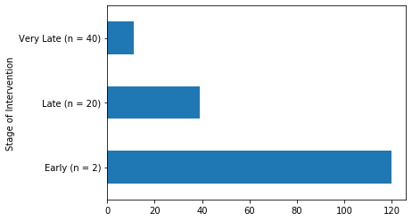

```python
compare_x.max_x.plot.barh()
```

As we can see from the graph, the later the stage of intervention, the smaller the group size we should allow to remain open.

This data presents the importance of early intervention to minimize the socioeconomic impact as much as possible.

## Recommendation

Given our analysis, we recommend that government officials and other key decision makers implement or recommend the following guidelines when structuring their NPI policies:

1. Explain the importance of NPIs to the general public.
2. Assess the stage of intervention.
   - if there are around 2 people already infected, then it is early stage
   - if there are around 20 people already infected, then it is late stage
   - if there are around 40 people already infected, then it is very late stage
3. Set limits on the maximum size of groups that are allowed to meet.
   - Less than 120 people for early stage (allows all groups to meet)
   - Less than 39 people for late stage
   - Less than 11 people for very late stage
4. Publish these guidelines and enforce them.
5. Continuously assess the situation. There will always be external factors, such as a surge in other ailments that may decrease the capcity within hospitals. Also, these recommendations are based on simulations which can not guarantee 100% accuracy. As such, it is important to adjust as situations change.

We have provided this analysis and recommendation as a guide for decision-makers. If there are any questions on our findings, please contact us at dso499@usc.edu.